# Simulation

Laura Cosgrove

11/27/2019

# Recreate Araujo et al. simulation

$Y_{irs} = \lambda_i + \beta_{ir} + \epsilon_{irs} + Z_{irs}\tau_i$

where $Y_{irs}$ is the measured outcome for occasion s, $s = 1, 2 $ of cycle r, $r = 1, 2, .... k$ for patient i, $i = 1, 2, n$, and:

- $\lambda_i \sim N(\Lambda, \phi^2)$: Patient-specific mean of the outcome, drawn from a normal distribution with population mean of $\Lambda$
- $\beta_{ir} \sim N(0, \gamma^2)$ : Within patient, within cycle (block) random noise
- $\epsilon_{irs} \sim N(0, \sigma^2)$ : Within patient, within cycle (block), within occassion (independent of treatment) random noise
- $\tau_{i} \sim N(T, \psi^2)$: Where $Z_{irs}$ takes values $\frac{1}{2}$ when the occassion $s$ has treatment A and $-\frac{1}{2}$ when occassion $s$ has treatment B, the patient-specific for treatment effect, drawn from a normal population mean treatment effect of T. Therefore, an estimate for HTE (heterogeneity of treatment effect) is $\psi^2$.

From our PREEMPT study setting:

“The sample size required for the proposed RCT is based on the primary outcome: change from baseline to 26 weeks on the PROMIS pain interference scale. Assuming that the minimally important difference is 0.4 SD difference (4 points) and that 10% of those who enter the study will not complete an endpoint and will therefore be assigned a change of 0, the full sample (endpoint completers plus non-completers) would need to show a 3.6-point difference in order for the completers to show a minimally important difference. Assuming a common standard deviation of 10 points, each group (Trialist app and usual care) would need to include 122 patients (244 in total) in order to have 80% power to detect a 3.6-point difference in means using a 2-group t-test with a 0.05 2-sided significance level.”

Reference: PROMIS scores have a mean of 50 and standard deviation (SD) of 10 in a clinically relevant referent population. Assume division by 10 in the PREEMPT case.

1. Set parameter values

```r
#cycles, treatments, n
k = 4
s = 2
n = 34

#priors
##lambda_i
Lambda = 50
phi = 10

##beta_ir: choose sd that's lower than meaningful change (0.4)
gamma = 4

##epsilon_irs: choose same sd as within cycle change
sigma = 2

##tau: simulate T to be treatment effect under minimum importance
## simulate hte to be the variance if 1/4 of population had T
T = 4
psi = 8
```

2. Set the block randomization schedule for patients

```r
library(blockrand)
library(tidyverse)
set.seed(12)

#functions
block_rand = function(n_cycles = k, n_tx = s, char_tx = c("A", "B")) {

blockrand(n = n_tx*n_cycles, num.levels = n_tx, levels = char_tx, block.sizes = 1) %>%
    pull(treatment)

}


get_n_blockrands = function(n_pt = n, n_cycles = k, n_tx = s, char_tx = c("A", "B")) {

rand_df <- tibble(id = 1:n_pt) %>%
  mutate(rand = map(id, ~block_rand(n_cycles, n_tx, char_tx)))

rand_df
}

#Example Demonstration
block_rand()
```

```
## [1] B A A B A B B A
## Levels: A B
```

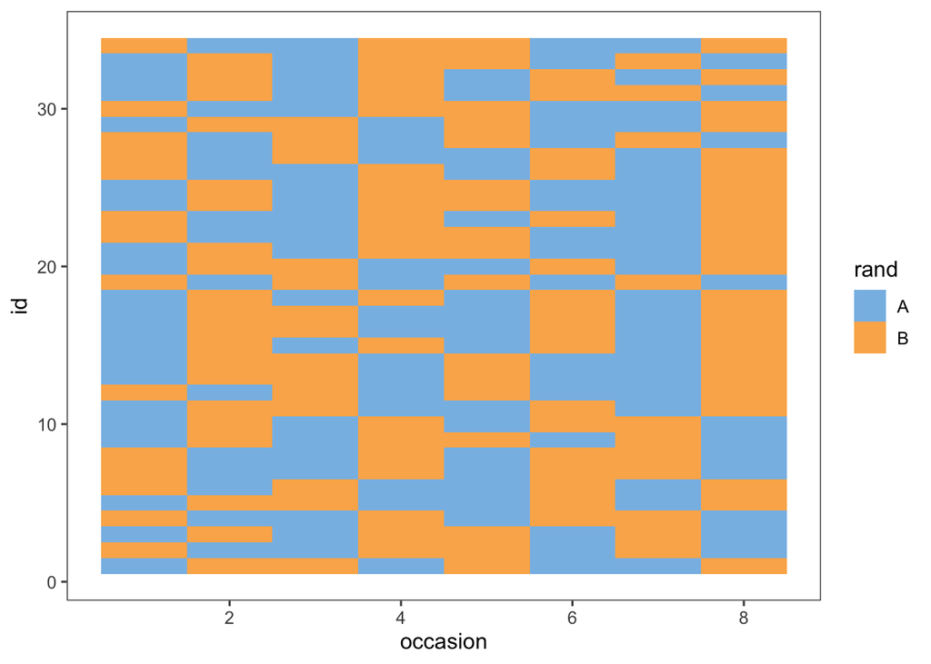

```r
rand_df <- get_n_blockrands()

rand_df %>%
  unnest_longer(col = rand) %>%
  group_by(id) %>%
  mutate(occasion = 1:(s*k)) %>%
  ggplot(aes(y = id, x = occasion, fill = rand)) +  geom_tile() + ggthemes::scale_fill_few() + ggthemes::theme_few()
```

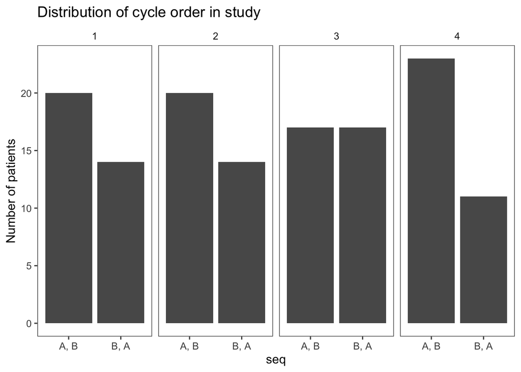

```r
seq_df <- rand_df %>%
  unnest_longer(col = rand) %>%
  group_by(id) %>%
  mutate(cycle = rep(1:k, each = 2)) %>%
  nest(-c("id", "cycle"), data = c(rand)) %>%
  mutate(seq = map_chr(data, ~.x  %>% pull(rand) %>% stringr::str_flatten(., collapse = ", "))) %>%
  select(-data) %>%
  mutate(seq = factor(seq))

seq_df %>%
  group_by(cycle, seq) %>% count() %>%
  ggplot(aes(x = seq, y = n)) +  geom_col(position = "dodge") + facet_grid(~cycle) + ggthemes::theme_few() + labs(title = "Distribution of cycle order in study", y = "Number of patients")
```

3. Choose a patient i and simulate a value $\lambda_i$ and another value $\tau_i$. These are to be retained and used until all values for that patient have been generated.

```r
set.seed(11)

rand_df <- rand_df %>%
  mutate(lambda = map_dbl(id, ~rnorm(1, mean = Lambda, sd = phi))) %>%
  mutate(tau = map_dbl(id, ~rnorm(1, T, psi)))
```

4. Generate a value $\beta_{ir}$ for cycle r of patient i. This is to be retained and used for both occasions of that cycle of that patient’s course of treatments

```r
set.seed(10)

rand_df <- rand_df %>%
  unnest_longer(col = rand) %>%
  group_by(id) %>%
  mutate(cycle = rep(1:k, each = 2)) %>%
  nest(data = c(rand)) %>% rename(rand = data) %>%
  mutate(beta = map_dbl(id, ~rnorm(1, mean = 0, sd = gamma)))
```

```r
set.seed(9)

rand_df <- rand_df %>%
  mutate(X = map_dbl(id, ~rnorm(1, mean = 0, sd = 1)))
```

6. Generate a value $\epsilon_{irs}$ for occasion s of cycle r for patient i.

```r
set.seed(8)

rand_df <- rand_df %>%
  mutate(rand = map(rand, ~unlist(.x))) %>%
  mutate(measure = list(c(1, 2))) %>%
  unnest_longer(col = rand) %>% unnest_longer(col = measure) %>%
  select(-rand_id) %>%
  mutate(epsilon = map_dbl(rand, ~rnorm(1, mean = 0, sd = sigma)))
```

7. Calculate the response as the sum of the value of $\lambda_i$ for that patient $\beta_ir$ for that cycle, $\epsilon_{irs}$ for that occasion and the product of $\tau_i$ for that patient multiplied by $Z_irs$ for that occasion.

```r
rand_df <- rand_df %>%
  mutate(Z = if_else(rand == "A", 1/2, -1/2)) %>%
  mutate(Y = lambda + beta + epsilon + tau*Z) %>%
  select(id, cycle, rand, Y, lambda, beta, epsilon, Z, tau)

rand_df
```

```
## # A tibble: 544 x 9
## # Groups:   id [34]
##       id cycle rand      Y lambda    beta epsilon     Z   tau
##    <int> <int> <fct> <dbl>  <dbl>   <dbl>   <dbl> <dbl> <dbl>
##  1     1     1 A      42.5   44.1  0.0750  -0.169   0.5 -2.96
##  2     1     1 A      44.4   44.1  0.0750   1.68    0.5 -2.96
##  3     1     1 B      44.7   44.1  0.0750  -0.927  -0.5 -2.96
##  4     1     1 B      44.5   44.1  0.0750  -1.10   -0.5 -2.96
##  5     1     2 B      46.3   44.1 -0.737    1.47   -0.5 -2.96
##  6     1     2 B      44.6   44.1 -0.737   -0.216  -0.5 -2.96
##  7     1     2 A      41.5   44.1 -0.737   -0.341   0.5 -2.96
##  8     1     2 A      39.7   44.1 -0.737   -2.18    0.5 -2.96
##  9     1     3 B      34.1   44.1 -5.49    -6.02   -0.5 -2.96
## 10     1     3 B      38.9   44.1 -5.49    -1.19   -0.5 -2.96
## # … with 534 more rows
```

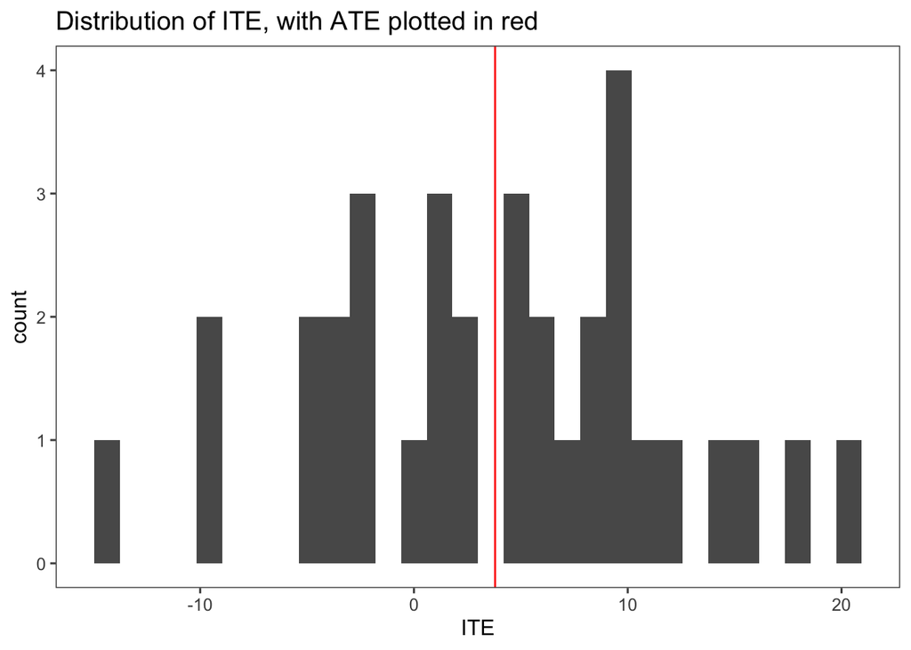

```r
rand_df %>%
  group_by(id, rand) %>%
  summarize(Y_bar = mean(Y)) %>%
  ungroup() %>%
  pivot_wider(names_from = rand, values_from = Y_bar) %>%
  group_by(id) %>%
  summarize(ITE = A - B) %>%
  mutate(ATE = mean(ITE))  %>%
  ggplot(aes(x = ITE)) + geom_histogram() + geom_vline(aes(xintercept = ATE, slope = 0), color = "red") + ggthemes::theme_few() + labs(title = "Distribution of ITE, with ATE plotted in red")
```

# Analyze series of n of 1 trials

$$Y_{irs} = \lambda_i + \beta_{ir} + \epsilon_{irs} + Z_{irs}\tau_i$$
Set up functions to create the datasets:

```r
set.seed(1)
library(lme4)
analysis_df <- rand_df %>%
  select(id, rand, cycle, Z, Y) %>%
  ungroup()


mod = lme4::lmer(Y ~ 1 + Z + (1|id:cycle) + (Z|id) , data = analysis_df)
summary(mod)
```

```
## Linear mixed model fit by REML ['lmerMod']
## Formula: Y ~ 1 + Z + (1 | id:cycle) + (Z | id)
##    Data: analysis_df
##
## REML criterion at convergence: 2923.3
##
## Scaled residuals:
##     Min      1Q  Median      3Q     Max
## -2.4860 -0.5310  0.0193  0.5868  2.2119
##
## Random effects:
##  Groups   Name        Variance Std.Dev. Corr
##  id:cycle (Intercept) 12.036   3.469
##  id       (Intercept) 57.372   7.574
##           Z           63.433   7.964    0.03
##  Residual              4.464   2.113
## Number of obs: 544, groups:  id:cycle, 136; id, 34
##
## Fixed effects:
##             Estimate Std. Error t value
## (Intercept)   45.649      1.336  34.176
## Z              3.796      1.378   2.755
##
## Correlation of Fixed Effects:
##   (Intr)
## Z 0.027
```

Here, we can see that our parameter values are recovered to a large degree.

- We set $\phi$ in $\lambda_i \sim N(\Lambda, \phi^2)$, the standard deviation of the patient-specific mean of the outcome, drawn from a normal distribution with population mean of $\Lambda$, to be 10. Here, the corresponding estimate in the variance of the outcome is under random effects of `id`, where it is 7.57.
- We set $\Lambda$ in $\lambda_i \sim N(\Lambda, \phi^2)$, to be 50. Here, the corresponding estimate in the mean of the outcome is under fixed effects, where it estimated as 45.65.
- We set $\gamma$ in $\beta_{ir} \sim N(0, \gamma^2)$, the within patient, within cycle (block) random noise, to be 4. Here, the corresponding estimate in the mean of the outcome is under random effects, `id:cycle` where it estimated as 3.47.
- We set $\sigma$ in $\epsilon_{irs} \sim N(0, \sigma^2)$, the within patient, within cycle (block), within occassion (independent of treatment) random noise to be 2: here, it is the residual random effects variance, where it is estimated to be 2.11.
- We set T in $\tau_{i} \sim N(T, \psi^2)$, the population average treatment effect, to be 4. Here, it is estimated under the fixed effects Z term, as 3.79.
- We set $\psi$ in $\tau_{i} \sim N(T, \psi^2)$, the heterogeneity of treatment effect, to be 8. Here, it is estimated under the random effects slope term of Z by treatment, as 7.96.

# Operating characteristics

For the above simulation, the confidence interval of T contains 4, and this will be the determination of treatment effect recovery for the operating characteristics:

```r
broom::tidy(mod, "fixed", conf.int = TRUE)
```

```
## # A tibble: 2 x 6
##   term        estimate std.error statistic conf.low conf.high
##   <chr>          <dbl>     <dbl>     <dbl>    <dbl>     <dbl>
## 1 (Intercept)    45.6       1.34     34.2     43.0      48.3
## 2 Z               3.80      1.38      2.75     1.09      6.50
```

For the secondary outcome of estimating heterogeneity of treatment effects correctly, we will consider an interval of 7.2, 8.8 – 2 minimally-important standard deviations from the true heterogeneity of treatment effect – to be acceptable for the operating characteristics.

## Functions

```r
#function to block randomize
get_n_blockrands(n_pt = n, n_cycles = k, n_tx = s, char_tx = c("A", "B"))
```

```
## # A tibble: 34 x 2
##       id rand
##    <int> <list>
##  1     1 <fct [8]>
##  2     2 <fct [8]>
##  3     3 <fct [8]>
##  4     4 <fct [8]>
##  5     5 <fct [8]>
##  6     6 <fct [8]>
##  7     7 <fct [8]>
##  8     8 <fct [8]>
##  9     9 <fct [8]>
## 10    10 <fct [8]>
## # … with 24 more rows
```

```r
#function to create lambda and tau
get_pt_level_effects = function(dat, pop_mean_Y = Lambda, pop_sd_Y = phi, pop_ave_TE = T, pop_sd_TE = psi ) {
  dat %>%
  mutate(lambda = map_dbl(id, ~rnorm(1, mean = pop_mean_Y, sd = pop_sd_Y))) %>%
  mutate(tau = map_dbl(id, ~rnorm(1, pop_ave_TE, pop_sd_TE)))
}

get_cycle_level_effects = function(dat, n_cycles = k, sd_Y_cycles = gamma) {
dat %>%
  unnest_longer(col = rand) %>%
  group_by(id) %>%
  mutate(cycle = rep(1:n_cycles, each = 2)) %>%
  nest(data = c(rand)) %>% rename(rand = data) %>%
  mutate(beta = map_dbl(id, ~rnorm(1, mean = 0, sd = sd_Y_cycles)))
}

get_occasion_level_effects = function(dat, measurements = 2, sd_Y_occassion = sigma) {
dat %>%
  mutate(rand = map(rand, ~unlist(.x))) %>%
  mutate(measure = list(1:measurements)) %>%
  unnest_longer(col = rand) %>% unnest_longer(col = measure) %>%
  select(-rand_id) %>%
  mutate(epsilon = map_dbl(rand, ~rnorm(1, mean = 0, sd = sd_Y_occassion)))
}

get_tx_ind = function(dat, measurements = 2, char_tx = c("A", "B")) {
  dat %>%
  mutate(Z = if_else(rand == char_tx[[1]], 1/2, -1/2))
}

get_outcome = function(dat) {
  dat %>%
  mutate(Y = lambda + beta + epsilon + tau*Z) %>%
  select(id, cycle, rand, Y, lambda, beta, epsilon, Z, tau)
}
```

```r
set.seed(11)
nsim = 100
sim_df <- tibble(sim = 1:nsim) %>%
  mutate(data = map(sim, ~get_n_blockrands()))

sim_df <- sim_df %>%
  mutate(data = map(data, ~get_pt_level_effects(dat = .x))) %>%
  mutate(data = map(data, ~get_cycle_level_effects(dat = .x))) %>%
  mutate(data = map(data, ~get_occasion_level_effects(dat = .x))) %>%
  mutate(data = map(data, ~get_tx_ind(dat = .x))) %>%
  mutate(data = map(data, ~get_outcome(dat = .x)))
```

## Model fitting for OC

```r
set.seed(12)

fit_mod <- function(dat) {
  lme4::lmer(Y ~ 1 + Z + (1|id:cycle) + (Z|id) , data = dat)
}

sim_mod <- sim_df %>%
  mutate(mod = map(data, ~fit_mod(.x)))

sim_mod <- sim_mod %>%
  mutate(T_est = map_dbl(mod, ~broom::tidy(.x, "fixed", conf.int = TRUE) %>% filter(term == "Z") %>% pull(estimate))) %>%
  mutate(T_clow = map_dbl(mod, ~broom::tidy(.x, "fixed", conf.int = TRUE) %>% filter(term == "Z") %>% pull(conf.low))) %>%
  mutate(T_chigh = map_dbl(mod, ~broom::tidy(.x, "fixed", conf.int = TRUE) %>% filter(term == "Z") %>% pull(conf.high))) %>%
  mutate(hte_est = map_dbl(mod, ~broom::tidy(.x) %>% filter(term == "sd_Z.id") %>% pull(estimate))) %>%
  mutate(pass1 = if_else(T_clow <= T & T_chigh >= T, 1, 0)) %>%
  mutate(rej_sharp_null = if_else(T_clow <= 0 & T_chigh >= 0, FALSE, TRUE)) %>%
  mutate(wrong_selection = if_else(T < 0 & T_chigh > 0 | T > 0 & T_chigh < 0, TRUE, FALSE)) %>%
  mutate(hte_mse = sqrt((hte_est - psi)^2) )

sim_mod %>%
  count(rej_sharp_null)
```

```
## # A tibble: 2 x 2
##   rej_sharp_null     n
##   <lgl>          <int>
## 1 FALSE              9
## 2 TRUE              91
```

```r
sim_mod %>%
  count(wrong_selection)
```

```
## # A tibble: 1 x 2
##   wrong_selection     n
##   <lgl>           <int>
## 1 FALSE             100
```

```r
sim_mod %>%
  count(pass1)
```

```
## # A tibble: 2 x 2
##   pass1     n
##   <dbl> <int>
## 1     0     9
## 2     1    91
```

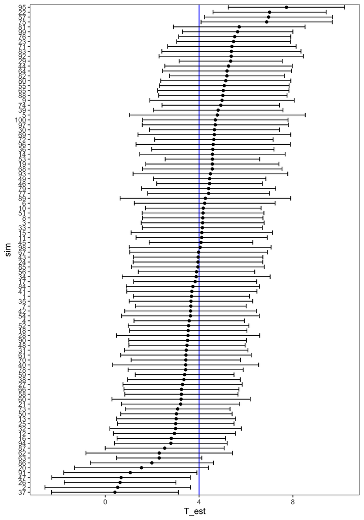

```r
sim_mod %>%
  mutate(sim = forcats::fct_reorder(factor(sim), T_est)) %>%
  ggplot(aes(x = sim, y = T_est)) +
  geom_hline(aes(yintercept = T), color = "blue") +
  geom_point() +
  geom_errorbar(aes(ymin = T_clow, ymax = T_chigh)) +
  coord_flip() +
  ggthemes::theme_few()
```

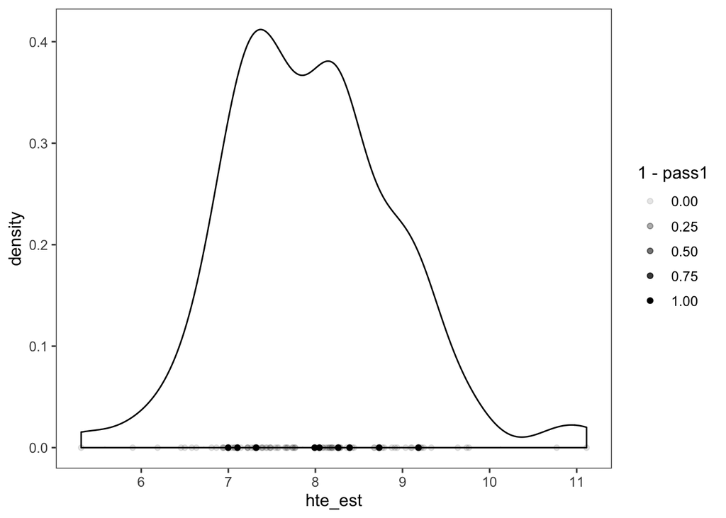

```r
sim_mod %>%
  ggplot(aes(x = hte_est)) + geom_density()+ geom_point(aes(y = 0, x = hte_est, alpha = 1 - pass1)) +
  ggthemes::theme_few()
```

```r
##final table
sim_mod %>%
  summarize(mean(rej_sharp_null),
            mean(wrong_selection),
            mean(pass1),
            mean(hte_mse)) %>%
  knitr::kable()
```

| mean(rej_sharp_null) | mean(wrong_selection) | mean(pass1) | mean(hte_mse) |
| --- | --- | --- | --- |
| 0.91 | 0 | 0.91 | 0.7694659 |

## refactoring

```r
m = 2
df_blockrand <- get_n_blockrands()
char_tx = c("A", "B")
df_blockrand %>%
    get_pt_level_effects(dat = ., pop_mean_Y = Lambda, pop_sd_Y = phi, pop_ave_TE = T, pop_sd_TE = psi) %>%
    get_cycle_level_effects(dat = ., n_cycles = k, sd_Y_cycles = gamma) %>%
    get_occasion_level_effects(dat = ., measurements = m, sd_Y_occassion = sigma) %>%
    get_tx_ind(dat = ., char_tx = char_tx) %>%
    get_outcome(dat = .)
```

```
## # A tibble: 544 x 9
## # Groups:   id [34]
##       id cycle rand      Y lambda   beta epsilon     Z   tau
##    <int> <int> <fct> <dbl>  <dbl>  <dbl>   <dbl> <dbl> <dbl>
##  1     1     1 B      47.3   40.5  2.67   3.48    -0.5 -1.29
##  2     1     1 B      46.0   40.5  2.67   2.17    -0.5 -1.29
##  3     1     1 A      45.1   40.5  2.67   2.62     0.5 -1.29
##  4     1     1 A      40.6   40.5  2.67  -1.92     0.5 -1.29
##  5     1     2 A      40.1   40.5 -0.712  0.961    0.5 -1.29
##  6     1     2 A      36.0   40.5 -0.712 -3.13     0.5 -1.29
##  7     1     2 B      42.8   40.5 -0.712  2.40    -0.5 -1.29
##  8     1     2 B      42.4   40.5 -0.712  2.00    -0.5 -1.29
##  9     1     3 A      38.3   40.5 -1.59   0.0560   0.5 -1.29
## 10     1     3 A      37.7   40.5 -1.59  -0.583    0.5 -1.29
## # … with 534 more rows
```